# Assignment #5

何思賢

## Date and Times & Advanced Visualization & Uncertainty

```r
library(tidyverse)
library(nycflights13)
```

### Problem 1.《R資料科學》238-240 頁

In [section 16.3.1](https://r4ds.had.co.nz/dates-and-times.html#getting-components), Hadley finds a strong pattern that flights leaving in minutes 20-30 and 50-60 within an hour have much lower delays than the rest of the hour. How can you explain such pattern?

*Note*: Hadley uses `avg_delay` to represent the average delay time of *arrival*. I think it would be more reasonable to use average delay time of *departure* instead. However, we still find the same pattern. You can refer to the code of this chapter I have provided.

*Hint*: You may refer to question 7 on [this page](https://r4ds.had.co.nz/dates-and-times.html#exercises-48) to get a reasonable explanation. But is it the whole story?

#### Answer:

The story may unfold as follows:

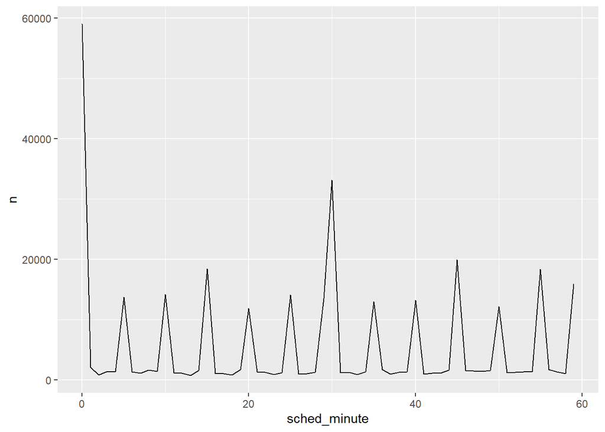

```r
make_datetime_100 <- function(year, month, day, time) {
    make_datetime(year, month, day, time %/% 100, time %% 100)
}

flights_dt <- flights %>%
    filter(!is.na(dep_time), !is.na(arr_time)) %>%
    mutate(
        dep_time = make_datetime_100(year, month, day, dep_time),
        arr_time = make_datetime_100(year, month, day, arr_time),
        sched_dep_time = make_datetime_100(year, month, day, sched_dep_time),
        sched_arr_time = make_datetime_100(year, month, day, sched_arr_time)
    ) %>%
    select(origin, dest, ends_with("delay"), ends_with("time")) %>%
    mutate(
        sched_minute = minute(sched_dep_time),
        minute = minute(dep_time),
        early = dep_delay < 0)

flights_dt %>%
    group_by(sched_minute) %>%
    summarise(n = n()) %>%
    ggplot(aes(sched_minute, n)) +
        geom_line()
```

2. To avoid congestion and delays at *half-hour* and *on-the-hour* departure times, airports often schedule flights to depart slightly earlier than these peak times. This results in a relatively high proportion of flights with **actual departure times** between *20-30 minutes* and *50-60 minutes* past the hour departing earlier than scheduled.

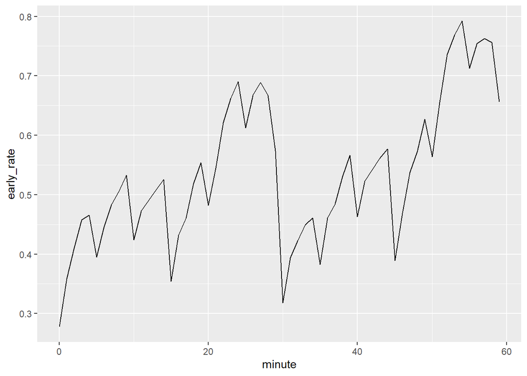

```r
flights_dt %>%
    group_by(minute) %>%
    summarise(early_rate = mean(early, na.rm = TRUE)) %>%
    ggplot(aes(minute, early_rate)) +
        geom_line()
```

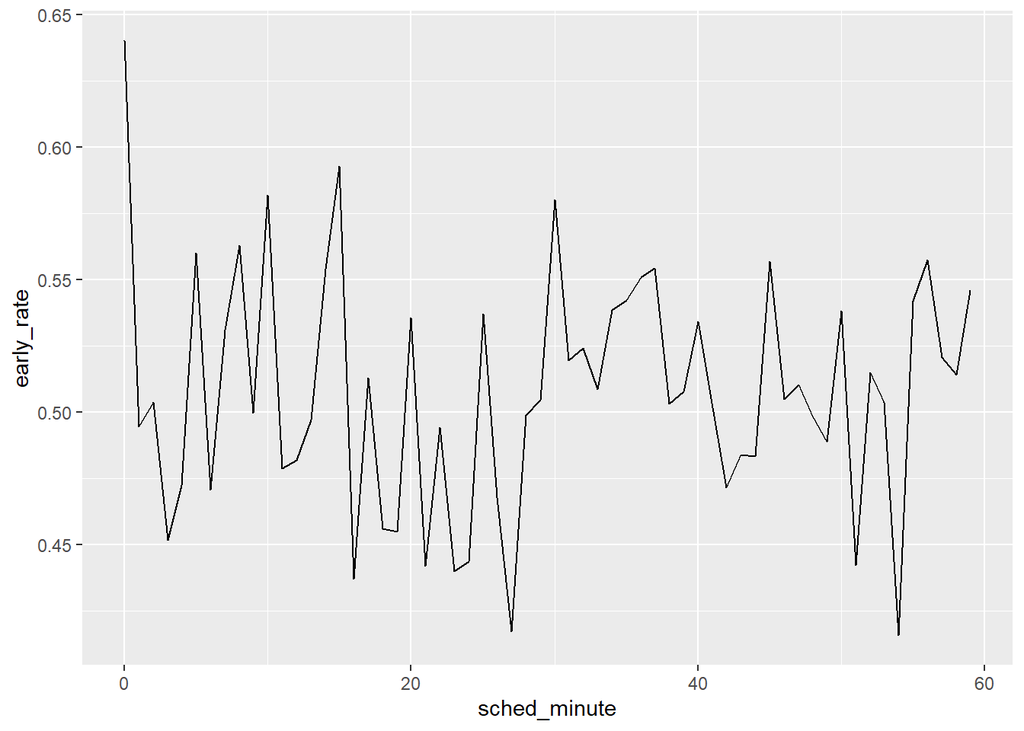

```r
flights_dt %>%
    group_by(sched_minute) %>%
    summarise(early_rate = mean(early, na.rm = TRUE)) %>%
    ggplot(aes(sched_minute, early_rate)) +
        geom_line()
```

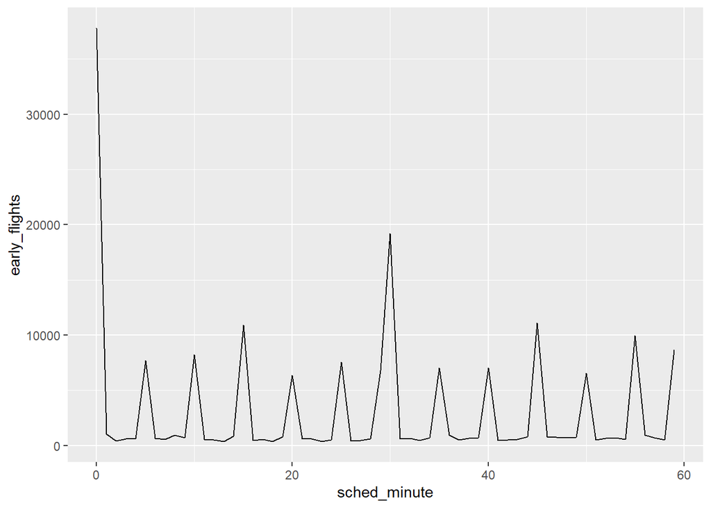

```r
flights_dt %>%
    group_by(sched_minute) %>%
    summarise(early_flights = sum(early, na.rm = TRUE)) %>%
    ggplot(aes(sched_minute, early_flights)) +
        geom_line()
```

4. Continuing from 2., flights departing between *20-30 minutes* and *50-60 minutes* past the hour tend to have a lower average delay time with **actual departure times** , owing to the fact that a significant proportion of these flights depart earlier than scheduled, thereby contributing negative values to the average delay time.

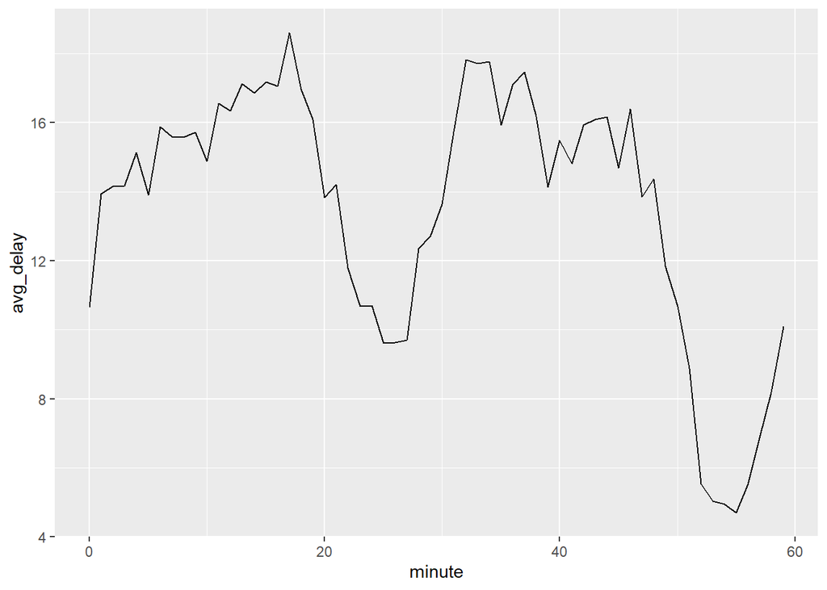

```r
flights_dt %>%
    group_by(minute) %>%
    summarise(avg_delay = mean(dep_delay, na.rm = TRUE)) %>%
    ggplot(aes(minute, avg_delay)) +
        geom_line()
```

5. However, there appears to be no clear pattern in the delay times during **scheduled departure times**, suggesting that the airport’s dispatching procedures are generally smooth and efficient.

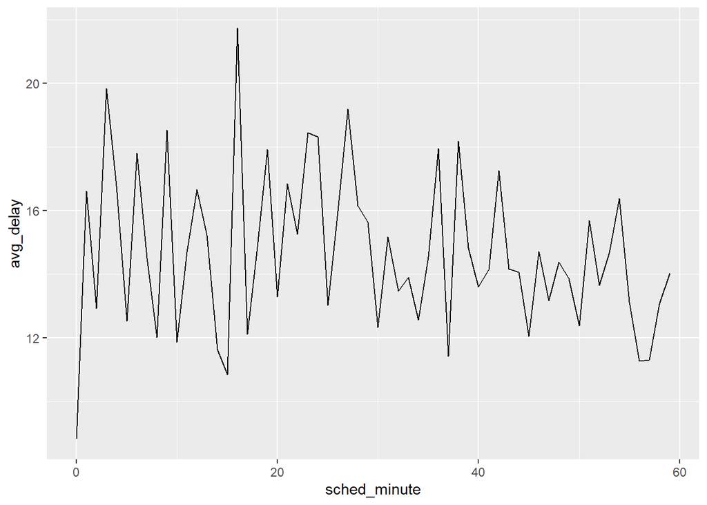

```r
flights_dt %>%
    group_by(sched_minute) %>%
    summarise(avg_delay = mean(dep_delay, na.rm = TRUE)) %>%
    ggplot(aes(sched_minute, avg_delay)) +
        geom_line()
```

### Problem 2.《R資料科學》242 頁第 2 題

Please refer to **question 2** on [this page](https://r4ds.had.co.nz/dates-and-times.html#exercises-48) and the end of [section 16.4.2](https://r4ds.had.co.nz/dates-and-times.html#periods). Please correct the errors in the columns `dep_time` and `arr_time` of the dataset `nycflights13::flights`, so we can make sure `dep_time = sched_dep_time + dep_delay` and `arr_time = sched_arr_time + arr_delay` always hold.

#### Answer:

In the end of [section 16.4.2](https://r4ds.had.co.nz/dates-and-times.html#periods), Hadley notes that some overnight flights were not accurately recorded the following day. It is worth noting that this error is not limited to the actual flight times, but also extends to the scheduled flight times where the scheduled arrival time is earlier than the departure time. Consequently, rectification should commence with the scheduled flight times.

If a flight is delayed, the actual departure or arrival time will be later than the scheduled time. However, if overnight stays are not accounted for correctly, the data may incorrectly indicate that the actual time is significantly earlier than the scheduled time, sometimes even by almost a full day.

In summary, the issue can be resolved in two steps:

1. Correct the overnight corrections that were not handled properly, which led to scheduled arrivals earlier than departures.
2. Adjust the actual departure or arrival time to accurately reflect the correct time, taking into consideration any discrepancies that may arise due to overnight stays between the scheduled and actual times.

```r
flights_dt %>%
    mutate(dep_time_ = sched_dep_time + dep_delay * 60) %>%
    filter(dep_time_ != dep_time) %>%
    select(dep_time_, dep_time, sched_dep_time, dep_delay)
```

```
## # A tibble: 1,205 × 4
##    dep_time_           dep_time            sched_dep_time      dep_delay
##    <dttm>              <dttm>              <dttm>                  <dbl>
##  1 2013-01-02 08:48:00 2013-01-01 08:48:00 2013-01-01 18:35:00       853
##  2 2013-01-03 00:42:00 2013-01-02 00:42:00 2013-01-02 23:59:00        43
##  3 2013-01-03 01:26:00 2013-01-02 01:26:00 2013-01-02 22:50:00       156
##  4 2013-01-04 00:32:00 2013-01-03 00:32:00 2013-01-03 23:59:00        33
##  5 2013-01-04 00:50:00 2013-01-03 00:50:00 2013-01-03 21:45:00       185
##  6 2013-01-04 02:35:00 2013-01-03 02:35:00 2013-01-03 23:59:00       156
##  7 2013-01-05 00:25:00 2013-01-04 00:25:00 2013-01-04 23:59:00        26
##  8 2013-01-05 01:06:00 2013-01-04 01:06:00 2013-01-04 22:45:00       141
##  9 2013-01-06 00:14:00 2013-01-05 00:14:00 2013-01-05 23:59:00        15
## 10 2013-01-06 00:37:00 2013-01-05 00:37:00 2013-01-05 22:30:00       127
## # ℹ 1,195 more rows
```

```r
flights_dt %>%
    mutate(arr_time_ = sched_arr_time + arr_delay * 60) %>%
    filter(arr_time_ != arr_time) %>%
    select(arr_time_, arr_time, sched_arr_time, arr_delay)
```

```
## # A tibble: 7,295 × 4
##    arr_time_           arr_time            sched_arr_time      arr_delay
##    <dttm>              <dttm>              <dttm>                  <dbl>
##  1 2013-01-02 10:01:00 2013-01-01 10:01:00 2013-01-01 19:50:00       851
##  2 2012-12-31 23:37:00 2013-01-01 23:37:00 2013-01-01 00:05:00       -28
##  3 2013-01-02 00:08:00 2013-01-01 00:08:00 2013-01-01 23:59:00         9
##  4 2012-12-31 23:45:00 2013-01-01 23:45:00 2013-01-01 00:17:00       -32
##  5 2013-01-02 00:06:00 2013-01-01 00:06:00 2013-01-01 23:23:00        43
##  6 2013-01-02 00:20:00 2013-01-01 00:20:00 2013-01-01 23:52:00        28
##  7 2013-01-02 00:46:00 2013-01-01 00:46:00 2013-01-01 20:40:00       246
##  8 2013-01-02 00:32:00 2013-01-01 00:32:00 2013-01-01 23:57:00        35
##  9 2013-01-02 00:21:00 2013-01-01 00:21:00 2013-01-01 21:10:00       191
## 10 2013-01-02 00:22:00 2013-01-01 00:22:00 2013-01-01 23:13:00        69
## # ℹ 7,285 more rows
```

```r
flights_dt %>%
  filter(sched_arr_time < sched_dep_time)
```

```
## # A tibble: 6,005 × 12
##    origin dest  dep_delay arr_delay dep_time            sched_dep_time
##    <chr>  <chr>     <dbl>     <dbl> <dttm>              <dttm>
##  1 EWR    BQN           9        -4 2013-01-01 19:29:00 2013-01-01 19:20:00
##  2 EWR    LAX           5       -28 2013-01-01 20:35:00 2013-01-01 20:30:00
##  3 EWR    SJU          -6       -12 2013-01-01 21:02:00 2013-01-01 21:08:00
##  4 JFK    LAS          -7       -32 2013-01-01 21:03:00 2013-01-01 21:10:00
##  5 EWR    SFO          11       -14 2013-01-01 21:08:00 2013-01-01 20:57:00
##  6 LGA    FLL         -10        -2 2013-01-01 21:20:00 2013-01-01 21:30:00
##  7 JFK    LAX          -7       -24 2013-01-01 21:28:00 2013-01-01 21:35:00
##  8 EWR    FLL          -9       -14 2013-01-01 21:36:00 2013-01-01 21:45:00
##  9 JFK    SJU           5       -14 2013-01-01 21:40:00 2013-01-01 21:35:00
## 10 JFK    MCO           2         2 2013-01-01 21:57:00 2013-01-01 21:55:00
## # ℹ 5,995 more rows
## # ℹ 6 more variables: arr_time <dttm>, sched_arr_time <dttm>, air_time <dbl>,
## #   sched_minute <int>, minute <int>, early <lgl>
```

```r
flights_dt %>%
    mutate(overnight = sched_arr_time < sched_dep_time,
           sched_arr_time = sched_arr_time + days(overnight),
           dep_time = sched_dep_time + dep_delay * 60,
           arr_time = sched_arr_time + arr_delay * 60) %>%
    filter(arr_time < dep_time)
```

```
## # A tibble: 0 × 13
## # ℹ 13 variables: origin <chr>, dest <chr>, dep_delay <dbl>, arr_delay <dbl>,
## #   dep_time <dttm>, sched_dep_time <dttm>, arr_time <dttm>,
## #   sched_arr_time <dttm>, air_time <dbl>, sched_minute <int>, minute <int>,
## #   early <lgl>, overnight <lgl>
```

### Problem 3. 鐵達尼號資料的視覺化：平行集圖（又名沖積圖）

Please download the famous [Titanic train data](https://www.dropbox.com/s/shf2rnrivwa9uig/titanic_train.csv?dl=0). You may refer to [the kaggle page](https://www.kaggle.com/competitions/titanic/data) for more details of the data. Visualize the data with the *parallel-sets diagram*, aka the *alluvial diagram*. See [section 11.3](https://clauswilke.com/dataviz/nested-proportions.html) of the book *Fundamentals of Data Visualization* for the introduction of the parallel-sets diagram. You are expected to use the `ggforce` or `ggalluvial` package. Your visualization is expected to look like the graph below.

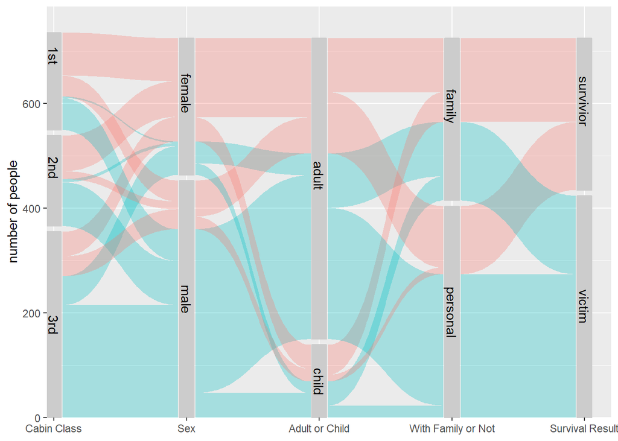

#### Answer:

```r
library(ggforce)
titanic <- read_csv("../data/titanic_train.csv")
(df <- titanic %>%
    mutate(
        # Result = if_else(Survived == 1, 'survived', 'perished') %>%
        #     factor() %>% fct_relevel('survived'),
        # Result = factor(
        #     if_else(Survived == 1,
        #             'survived',
        #             'perished'
        #     ),
        #     levels = c('survived', 'perished')
        # ),

        # 用改變 level 的各種寫法, 怎麼改都沒有辦法把 survived 放在 perished 上面
        # 底下方法才成功, 注意 survived 前有一個空格
        Result = if_else(Survived == 1, " survived", "perished"),
        Class = case_when(
            Pclass == 1 ~ "1st",
            Pclass == 2 ~ "2nd",
            Pclass == 3 ~ "3rd"
        ),
        Age_group = cut(
            # Age, breaks = c(0, 3, 12, 20, 55, 100),
            # labels = c('infant', 'kid', 'teenager', 'adult', 'aged')
            Age, breaks = c(0, 18, 100),
            labels = c('child', 'adult')
        ),
        Family = if_else(SibSp > 0 | Parch > 0, 'family', 'personal')
    ) %>%
    select(Class, Sex, Age_group, Family, Result) %>%
    drop_na() # drop 177 rows; all na's are in Age_group
)
```

```
## # A tibble: 714 × 5
##    Class Sex    Age_group Family   Result
##    <chr> <chr>  <fct>     <chr>    <chr>
##  1 3rd   male   adult     family   "perished"
##  2 1st   female adult     family   " survived"
##  3 3rd   female adult     personal " survived"
##  4 1st   female adult     family   " survived"
##  5 3rd   male   adult     personal "perished"
##  6 1st   male   adult     personal "perished"
##  7 3rd   male   child     family   "perished"
##  8 3rd   female adult     family   " survived"
##  9 2nd   female child     family   " survived"
## 10 3rd   female child     family   " survived"
## # ℹ 704 more rows
```

```r
(df <- df %>%
    group_by(Class, Sex, Age_group, Family, Result) %>%
    count()
)
```

```
## # A tibble: 41 × 6
## # Groups:   Class, Sex, Age_group, Family, Result [41]
##    Class Sex    Age_group Family   Result          n
##    <chr> <chr>  <fct>     <chr>    <chr>       <int>
##  1 1st   female child     family   " survived"     9
##  2 1st   female child     family   "perished"      1
##  3 1st   female child     personal " survived"     1
##  4 1st   female adult     family   " survived"    42
##  5 1st   female adult     family   "perished"      1
##  6 1st   female adult     personal " survived"    30
##  7 1st   female adult     personal "perished"      1
##  8 1st   male   child     family   " survived"     4
##  9 1st   male   child     family   "perished"      1
## 10 1st   male   adult     family   " survived"    16
## # ℹ 31 more rows
```

```r
data <- gather_set_data(df, 1:5)
(data <- data %>% mutate(
    x = factor(
        case_when(
            x == 1 ~ "Cabin Class",
            x == 2 ~ "Sex",
            x == 3 ~ "Adult or Child",
            x == 4 ~ "With Family or Not",
            x == 5 ~ "Survival Result"
        ),
        levels = c("Cabin Class",
                   "Sex",
                   "Adult or Child",
                   "With Family or Not",
                   "Survival Result")
        )
    )
)
```

```
## # A tibble: 205 × 9
## # Groups:   Class, Sex, Age_group, Family, Result [41]
##    Class Sex    Age_group Family   Result          n    id x           y
##    <chr> <chr>  <fct>     <chr>    <chr>       <int> <int> <fct>       <chr>
##  1 1st   female child     family   " survived"     9     1 Cabin Class 1st
##  2 1st   female child     family   "perished"      1     2 Cabin Class 1st
##  3 1st   female child     personal " survived"     1     3 Cabin Class 1st
##  4 1st   female adult     family   " survived"    42     4 Cabin Class 1st
##  5 1st   female adult     family   "perished"      1     5 Cabin Class 1st
##  6 1st   female adult     personal " survived"    30     6 Cabin Class 1st
##  7 1st   female adult     personal "perished"      1     7 Cabin Class 1st
##  8 1st   male   child     family   " survived"     4     8 Cabin Class 1st
##  9 1st   male   child     family   "perished"      1     9 Cabin Class 1st
## 10 1st   male   adult     family   " survived"    16    10 Cabin Class 1st
## # ℹ 195 more rows
```

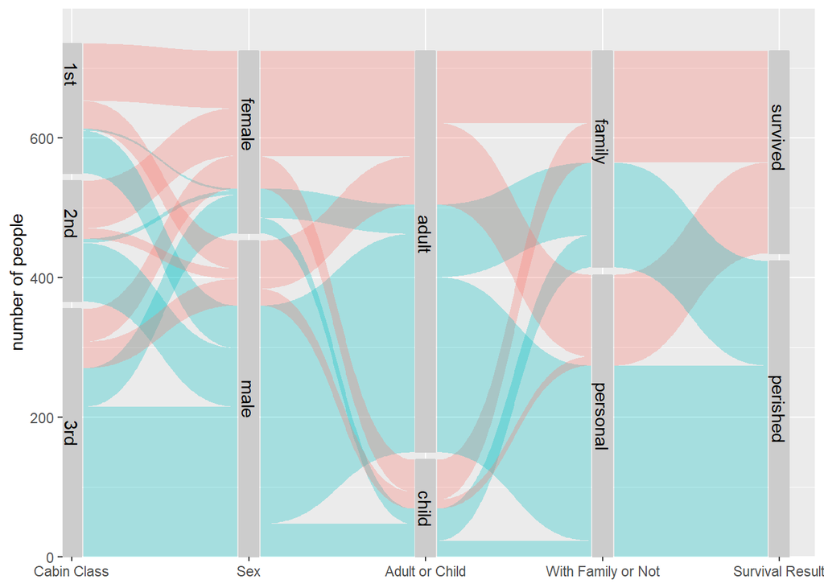

```r
# data %>% View()

ggplot(data, aes(x, id = id, split = y, value = n)) +
    geom_parallel_sets(aes(fill = Result),
        sep = 0.015, # the proportional separation between categories within a variable
        alpha = 0.3,
        axis.width = 0.13,
        show.legend = FALSE) +
    geom_parallel_sets_axes(
        axis.width = 0.11,
        sep = 0.015, # the proportional separation between categories within a variable
        fill = "grey80", color = "grey80") +
    geom_parallel_sets_labels(colour = 'black') +
    scale_x_discrete(
        name = NULL,
        expand = expansion(mult = 0, add = c(0, 0.2))
    ) +
    scale_y_continuous(
        name = "number of people",
        expand = c(0, 0)
    )
```

### Problem 4. 不確定性: 基礎觀念

Please read [Chapter 16](https://clauswilke.com/dataviz/visualizing-uncertainty.html) of the book *Fundamentals of Data Visualization*. Answer the following questions in your own words.

1. What is the difference between the *standard deviation* and the *standard error*? What is the connection between them?
2. See figure 16.15. Claus Wilke gives an intuitive explanation to the shape of a confidence band based on simulation. But we indeed know that `ggplot2` produces the plot by direct calculation. Please explore the reasons for the formation of the shape of a confidence band, and give an intuitive or a rigorous explanation. You shall confirm your statement by simulating or real data.

*Hint*: At least, you shall answer where the bandwidth is narrowest. If you have spare time, you can think about what the shape of the confidence band is.

#### Answer:

1. The standard deviation (SD) is a measure of the amount of variation or dispersion of a set of values. In other words, the SD measures the spread of data around the mean, and it provides a measure of how much individual data points deviate from the mean. The SD quantifies *scatter — how much the values vary from one another*.

   The standard error (SE) of a statistic (usually an estimate of a parameter) is *the standard deviation of its sampling distribution* or **an estimate of that standard deviation**. In other words, the SE is a measure of the uncertainty in an estimate of a population parameter based on samples.

   If the statistic is the sample mean, it is called the standard error of the mean (SEM). SEM quantifies *how precisely you know the true mean of the population*. **It takes into account both the value of the SD and the sample size**: The larger the SD, the larger the SEM; the larger the sample size, the smaller the SEM.
2. See [the page](https://stats.stackexchange.com/questions/85560/) for details. Assume the data $\{(y_i, x_i)|_{i=1,\cdots,N}\}$ is generated by the **real model** $y=\beta_0+ \beta_1 x + \varepsilon$, where **$x$ is non-stochastic** and $\varepsilon \overset{iid}{\sim} N(0,\sigma^2)$. Denote $\boldsymbol{\beta}=(\beta_0, \beta_1)'$, $\mathbf{y}=(y_1,\cdots,y_N)'$, $\boldsymbol{\varepsilon}=(\varepsilon_1,\cdots,\varepsilon_N)'$, and $\mathbf{X}=\left(\begin{array}{ccc}1, & \cdots, & 1\\x_1, & \cdots, & x_N \end{array}\right)'$. Then, we can rewite the model as $\mathbf{Y}=\mathbf{X}\boldsymbol{\beta}+\boldsymbol{\varepsilon}$. When running a linear regression on the data, the estimator for $\boldsymbol{\beta}$, is $\hat{\boldsymbol{\beta}}=(\mathbf{X}'\mathbf{X})^{-1}\mathbf{X}'\mathbf{y}$, and the covariance matrix for $\hat{\boldsymbol{\beta}}$, is $Var(\hat{\boldsymbol{\beta}})=(\mathbf{X}'\mathbf{X})^{-1}\mathbf{X}'\cdot Var(\mathbf{y})\cdot\mathbf{X}(\mathbf{X}'\mathbf{X})^{-1}=(\mathbf{X}'\mathbf{X})^{-1}\mathbf{X}'\cdot\sigma^2\mathbf{I}\cdot\mathbf{X}(\mathbf{X}'\mathbf{X})^{-1}=\sigma^2(\mathbf{X}'\mathbf{X})^{-1}$.

   It then follows that the fitted value for some $x=h$ is $\hat{y}=\hat{\beta}_0+\hat{\beta}_1h$, with the variace being $Var\left(\hat{\beta}_0+\hat{\beta}_1h\right)=Var(\hat{\beta}_0)+2Cov(\hat{\beta}_0,\hat{\beta}_1)h+Var(\hat{\beta_1)}h^2$, which equals to $Var(\hat{\beta}_1)\left(h+\frac{Cov(\hat{\beta}_0,\hat{\beta}_1)}{Var(\hat{\beta}_1)}\right)^2+\frac{1}{Var(\hat{\beta}_1)}\left[Var(\hat{\beta}_0)Var(\hat{\beta}_1)-Cov(\hat{\beta}_0,\hat{\beta}_1)^2\right]=\sigma^2\left(\frac{(h-\bar{x})^2}{\sum (x_i-\bar{x})^2}+\frac{1}{N}\right)$.

   Then the confidence bandwidth at $h$ is a fixed multiple (related to choice of confidence level) of $\sigma\sqrt{\frac{(h-\bar{x})^2}{\sum (x_i-\bar{x})^2}+\frac{1}{N}}$. The bandwidth would be narrowest at $h=\bar{x}$, and the shape would be hyperbolic.

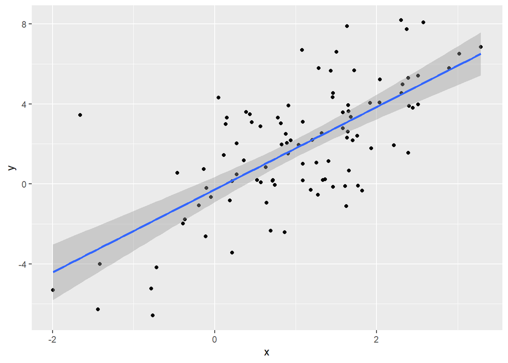

```r
conf_sim <- function(n, sigma = 2.5, cv_level = .95) {
    set.seed(42)
    df <- tibble(
        x = rnorm(n, mean = 1, sd = 1),
        err = rnorm(n, sd = sigma),
        y = 2 * x + err
    )
    #mod <- lm(y ~ x, data = df)
    #summary(mod)
    ggplot(df, aes(x,y)) +
        geom_point() +
        geom_smooth(method = lm, level = cv_level)
}

# The narrowest bandwidth is about sigma/(n)^(1/2) * 4 if cv_level = .95.
# When sigma = 2.5 and n = 100 (or 25), the narrowest bandwidth is about 1 (or 2).
conf_sim(100)
```

While the above argument relies solely on mathematical derivation, the concept of sample redrawing remains informative. In the code below, the confidence band (indicated by the red dashed lines) is created using the original data, while the line cluster (represented by the green lines) is generated by repeatedly applying regression on randomly redrawn samples from the original data.

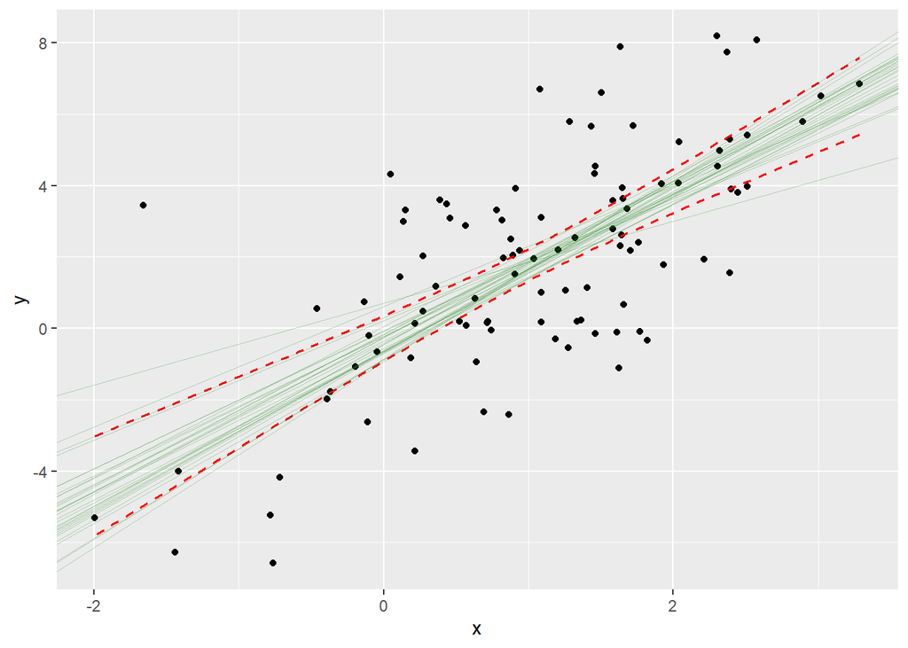

```r
lm_coeffs <- function(df) {
    coeffs <- set_names(
        df %>% lm(y ~ x, data = .) %>% coefficients,
        c("beta_0", "beta_1")
    )
    coeffs
}

sample_lm_coeffs <- function(df, n_sample = 15) {
    coeffs <- df %>% sample_n(n_sample, replace = TRUE) %>% lm_coeffs
    coeffs
}

resample_lm_coeffs <- function(df, n_rep = 30, n_sample = 100) {
    set.seed(42)
    coeffs <- tibble(
        beta_0 = rep(0, n_rep),
        beta_1 = rep(0, n_rep)
    )

    for (j in 1:n_rep){
        coeffs[j, ] <- as.list(sample_lm_coeffs(df, n_sample))
    }
    coeffs
}

conf_sample_sim <- function(n = 100, n_sample = 100, n_rep =30, sigma = 2.5, cv_level = .95) {
    set.seed(42)
    tb <- tibble(
        x = rnorm(n, mean = 1, sd = 1),
        err = rnorm(n, sd = sigma),
        y = 2 * x + err
    )

    coeffs <- resample_lm_coeffs(tb)

    ggplot(tb, aes(x, y)) +
        geom_point() +
        geom_ribbon(stat = "smooth", method = "lm", level = cv_level, colour = "red", fill = NA,
                    linewidth = 0.7, linetype = 'dashed') +
        geom_abline(aes(intercept = beta_0, slope = beta_1), data = coeffs,
                    linewidth = 0.3, alpha = 0.3, color='forestgreen')
}

conf_sample_sim()
```

### Problem 5. 頻率學派（置信區間）vs. 貝氏學派（可信區間）

Please read the two discussion threads below (and the references attached): [thread 1](https://stats.stackexchange.com/questions/26450/why-does-a-95-confidence-interval-ci-not-imply-a-95-chance-of-containing-the) and [thread 2](https://stats.stackexchange.com/questions/2356/are-there-any-examples-where-bayesian-credible-intervals-are-obviously-inferior). Try your best to answer the following questions:

1. What does a 95% *confidence interval* mean? What does a 95% *credible interval* mean?
2. Give an (artificial) example to show that *confidence interval* and *credible interval* may differ a lot.
3. After careful reading and thorough thinking, offer your personal opinion on both *frequentist approach* and *Bayesian approach*. If you really don’t have any opinion, don’t say anything.

### Bonus Problem. Monty Hall Problem Revisited

You participate in a TV game show where you are faced with three doors that are initially closed. Behind two of the doors, there are goats, and behind one of the doors, there is a car. The objective of the game is to guess which door has the car behind it. At the beginning of the game, the host Monty Hall asks you to choose one of the doors, and then opens one of the two remaining doors that has a goat behind it. The host then asks if you want to switch to the other closed door or stick with your initial choice.

Assuming that the host prefers to reveal a goat for dramatic effect, he will avoid opening the door with the car behind it if he knows which door it is. If he doesn’t know, he might accidentally open the door with the car behind it.

1. Prove the following statement: **If the host knows which door has the car, then switching doors will result in a win with a probability of $\frac{2}{3}$. If he doesn’t know, the probability of winning is the same for switching or sticking with the initial choice, which is $\frac{1}{2}$.** Therefore, switching doors is always the (weakly) dominant strategy.

Now, let’s assume that you are uncertain whether the host knows which door has the car. Your *prior* belief about whether the host knows is represented by the probability $p$. The key is that the host’s actions and the outcome will modify your *posterior* belief about whether the host knows or not, according to the Bayesian probability law. It is easy to imagine that, given the outcome of “the host has opened a door with a goat behind it,” your posterior belief about the host’s knowledge will be updated to $p'$. In this case, the probability of winning by switching doors is a weighted average of $\frac{2}{3}$ and $\frac{1}{2}$, where the weights are $(p', 1-p')$, not $(p, 1-p)$. That is, the probability of winning by switching doors is $\frac{2}{3}p' + \frac{1}{2}(1-p')$, not $\frac{2}{3}p + \frac{1}{2}(1-p)$.

2. Prove that the relationship between $p'$ and $p$ is **$p' = \frac{p}{p+\frac{2}{3}(1-p)}$**. Moreover, show that the following interesting result: **If the audience has watched the show several times, and the host has always opened a door with a goat, assuming that the host always knows or never knows, then as long as the initial belief $p_0$ is between $0$ and $1$, the posterior probability after watching the show $n$ times ($p_n$) will converge to $1$**. In the long run, the probability of winning by switching doors converges to $\frac{2}{3}$.

If we assume that the host’s behavior criterion and information are consistent, then from the consistent outcome, we can “infer”, rather than “assume”, that he knows in advance where the car is. This exemplifies the old adage: a person’s heart will be revealed by time (日久見人心).

#### Answer:

**First, I provide a tedious approach:**

1. Let $H$ denote the event that the host knows which door has the car. Let $H^C$ denote the event that the host does not know which door has the car. Then, $\mbox{Pr}(H)=p$. Let $E$ denote the event that you choose the door (say door 1) with the car *at the beginning*. Then, $\mbox{Pr}(E)=\frac{1}{3}$. (Note: event $H$ and event $E$ are independent.)

Let $D$ denote the event that the door 3 has a goat, and let $G$ denote the event that the host chooses to opens door 3 with a goat behind it. (Note: $G \subseteq D$.)

Under $E$, we know that
$$\mbox{Pr}(G|E\cap H) = \mbox{Pr}(G|D\cap E\cap H)
\times \mbox{Pr}(D|E\cap H) = \frac{1}{2} \times 1 =
\frac{1}{2}$$
and
$$\mbox{Pr}(G|E\cap
H^C) = \mbox{Pr}(G|D\cap E\cap H^C) \times \mbox{Pr}(D|E\cap H^C) =
\frac{1}{2}\times 1 = \frac{1}{2}.$$

Under $E^C$, we know that
$$\mbox{Pr}(G|E^C\cap H) = \mbox{Pr}(G|D \cap E^C\cap H)\times
\mbox{Pr}(D|E^C\cap H) = 1 \times \frac{1}{2} = \frac{1}{2}$$
and
$$\mbox{Pr}(G|E^C\cap H^C) =
\mbox{Pr}(G|D\cap E^C\cap H^C)\times \mbox{Pr}(D|E^C\cap H^C) =
\frac{1}{2} \times \frac{1}{2} =\frac{1}{4}.$$

If $H$ occurs:
$$\mbox{Pr}(E|G\cap H)
=\frac{\mbox{Pr}(E\cap G\cap H)}{\mbox{Pr}(G\cap H)}
=\frac{\mbox{Pr}(E\cap G\cap H)}{\mbox{Pr}(E\cap G\cap
H)+\mbox{Pr}(E^C\cap G\cap H)}\\
=\frac{\mbox{Pr}(G|E\cap H)\mbox{Pr}(E\cap H)}{\mbox{Pr}(G|E\cap
H)\mbox{Pr}(E\cap H)+\mbox{Pr}(G|E^C\cap H)\mbox{Pr}(E^C\cap H)}\\
=\frac{\mbox{Pr}(G|E\cap H)\mbox{Pr}(E)\mbox{Pr}(H)}{\mbox{Pr}(G|E\cap
H)\mbox{Pr}(E)\mbox{Pr}(H)+\mbox{Pr}(G|E^C\cap
H)\mbox{Pr}(E^C)\mbox{Pr}(H)}\\
=\frac{\frac{1}{2}\times\frac{1}{3}\times
p}{\frac{1}{2}\times\frac{1}{3}\times
p+\frac{1}{2}\times\frac{2}{3}\times p}\\
=\frac{1}{3}.$$
If the host knows, switching doors will result in a win with a probability of
$$\mbox{Pr}(E^C|G\cap H) = 1 -
\mbox{Pr}(E|G\cap H) = \frac{2}{3}.$$

If $H^C$ occurs:
$$\mbox{Pr}(E|G\cap H^C)
=\frac{\mbox{Pr}(E\cap G\cap H^C)}{\mbox{Pr}(G\cap H^C)}
=\frac{\mbox{Pr}(E\cap G\cap H^C)}{\mbox{Pr}(E\cap G\cap
H^C)+\mbox{Pr}(E^C\cap G\cap H^C)}\\
=\frac{\mbox{Pr}(G|E\cap H^C)\mbox{Pr}(E\cap H^C)}{\mbox{Pr}(G|E\cap
H^C)\mbox{Pr}(E\cap H^C)+\mbox{Pr}(G|E^C\cap H^C)\mbox{Pr}(E^C\cap
H^C)}\\
=\frac{\mbox{Pr}(G|E\cap
H^C)\mbox{Pr}(E)\mbox{Pr}(H^C)}{\mbox{Pr}(G|E\cap
H^C)\mbox{Pr}(E)\mbox{Pr}(H^C)\mbox{Pr}(G|E^C\cap
H^C)\mbox{Pr}(E^C)\mbox{Pr}(H^C)}\\
=\frac{\frac{1}{2}\times\frac{1}{3}\times
(1-p)}{\frac{1}{2}\times\frac{1}{3}\times
(1-p)+\frac{1}{4}\times\frac{2}{3}\times (1-p)}\\
=\frac{1}{2}.$$

If the host doesn’t know, the probability of winning is the same for switching or sticking with the initial choice, which is $\frac{1}{2}$.

2. Given that $G$ ocuurs:
   $$\mbox{Pr}(H|G)
   = \frac{\mbox{Pr}(H\cap G)}{\mbox{Pr}(G)}\\
   = \frac{\mbox{Pr}(H\cap G\cap E)+\mbox{Pr}(H\cap G\cap
   E^C)}{\mbox{Pr}(H\cap G\cap E) + \mbox{Pr}(H \cap G\cap E^C) +
   \mbox{Pr}(H^C \cap G \cap E) + \mbox{Pr}(H^C \cap G \cap E^C)}\\
   = \frac{\mbox{Pr}(G| E\cap H)\mbox{Pr}(E)\mbox{Pr}(H)+\mbox{Pr}(G|E^C
   \cap H)\mbox{Pr}(E^C)\mbox{Pr}(H)}{\mbox{Pr}(G| E\cap
   H)\mbox{Pr}(E)\mbox{Pr}(H)+\mbox{Pr}(G|E^C \cap
   H)\mbox{Pr}(E^C)\mbox{Pr}(H) + \mbox{Pr}(G| E\cap
   H^C)\mbox{Pr}(E)\mbox{Pr}(H^C)+\mbox{Pr}(G|E^C \cap
   H^C)\mbox{Pr}(E^C)\mbox{Pr}(H^C)}\\
   = \frac{\frac{1}{2}\times\frac{1}{3}\times
   p+\frac{1}{2}\times\frac{2}{3}\times
   p}{\frac{1}{2}\times\frac{1}{3}\times
   p+\frac{1}{2}\times\frac{2}{3}\times p +
   \frac{1}{2}\times\frac{1}{3}\times
   (1-p)+\frac{1}{4}\times\frac{2}{3}\times (1-p)}\\
   =\frac{p}{p+\frac{2}{3}(1-p)},$$
   which is the posterior belief.

**A simpler approach is given below:**

1. Let $H$ denote the event that the host knows which door has the car. Let $H^C$ denote the event that the host does not know which door has the car. Then, $\mbox{Pr}(H)=p$. Let $E$ denote the event that you choose the door with the car *at the beginning*. Then, $\mbox{Pr}(E)=\frac{1}{3}$. (Note: event $H$ and event $E$ are independent.)

Let $F$ denote the event that the host opens a door with a goat behind it. Note that *the door in event $F$ is not specified, while the door in event $G$ (defined in the previous approach) is specified*.

Then, $\mbox{Pr}(F|E \cap H) = \mbox{Pr}(F|E \cap H^C) = \mbox{Pr}(F|E^C \cap H) = 1$, but $\mbox{Pr}(F|E^C \cap H^C) = \frac{1}{2}$ (because the host may open a door with a car behind it if he does not knows which door has the car).

If $H$ occurs:
$$\mbox{Pr}(E|F\cap H)
=\frac{\mbox{Pr}(E\cap F\cap H)}{\mbox{Pr}(F\cap H)}
=\frac{\mbox{Pr}(E\cap F\cap H)}{\mbox{Pr}(E\cap F\cap
H)+\mbox{Pr}(E^C\cap F\cap H)}\\
=\frac{\mbox{Pr}(F|E\cap H)\mbox{Pr}(E\cap H)}{\mbox{Pr}(F|E\cap
H)\mbox{Pr}(E\cap H)+\mbox{Pr}(F|E^C\cap H)\mbox{Pr}(E^C\cap H)}\\
=\frac{\mbox{Pr}(F|E\cap H)\mbox{Pr}(E)\mbox{Pr}(H)}{\mbox{Pr}(F|E\cap
H)\mbox{Pr}(E)\mbox{Pr}(H)+\mbox{Pr}(F|E^C\cap
H)\mbox{Pr}(E^C)\mbox{Pr}(H)}\\
=\frac{1\times\frac{1}{3}\times p}{1\times\frac{1}{3}\times
p+1\times\frac{2}{3}\times p}\\
=\frac{1}{3}.$$
If $H^C$ occurs:

$$\mbox{Pr}(E|F\cap H^C)
=\frac{\mbox{Pr}(E\cap F\cap H^C)}{\mbox{Pr}(F\cap H^C)}
=\frac{\mbox{Pr}(E\cap F\cap H^C)}{\mbox{Pr}(E\cap F\cap
H^C)+\mbox{Pr}(E^C \cap F\cap H^C)}\\
=\frac{\mbox{Pr}(F|E\cap H^C)\mbox{Pr}(E\cap H^C)}{\mbox{Pr}(F|E\cap
H^C)\mbox{Pr}(E\cap H^C)+\mbox{Pr}(F|E^C\cap H^C)\mbox{Pr}(E^C\cap
H^C)}\\
=\frac{\mbox{Pr}(F|E\cap
H^C)\mbox{Pr}(E)\mbox{Pr}(H^C)}{\mbox{Pr}(F|E\cap
H^C)\mbox{Pr}(E)\mbox{Pr}(H^C)\mbox{Pr}(F|E^C\cap
H^C)\mbox{Pr}(E^C)\mbox{Pr}(H^C)}\\
=\frac{1\times\frac{1}{3}\times (1-p)}{1\times\frac{1}{3}\times
(1-p)+\frac{1}{2}\times\frac{2}{3}\times (1-p)}\\
=\frac{1}{2}.$$
If the host doesn’t know, the probability of winning is the same for switching or sticking with the initial choice, which is $\frac{1}{2}$.

2. Given that $F$ ocuurs:
   $$\mbox{Pr}(H|F)
   = \frac{\mbox{Pr}(H\cap F)}{\mbox{Pr}(F)} =
   \frac{\mbox{Pr}(H\cap F)}{\mbox{Pr}(H\cap F) + \mbox{Pr}(E\cap H^C\cap
   F) + \mbox{Pr}(E^C\cap H^C\cap F) }\\
   = \frac{\mbox{Pr}(F|H)\mbox{Pr}(H)}{\mbox{Pr}(F|H)\mbox{Pr}(H) +
   \mbox{Pr}(F|E\cap H^C)\mbox{Pr}(E)\mbox{Pr}(H^C)+
   \mbox{Pr}(F|E^C\cap H^C)\mbox{Pr}(E^C)\mbox{Pr}(H^C)}\\
   =\frac{1\times p}{1\times
   p+1\times\frac{1}{3}\times(1-p)+\frac{1}{2}\times\frac{2}{3}\times(1-p)}\\
   =\frac{p}{p+\frac{2}{3}(1-p)};$$
   an alternative calculation method also gives
   $$\mbox{Pr}(H|F)
   = \frac{\mbox{Pr}(H\cap F)}{\mbox{Pr}(F)} =
   \frac{\mbox{Pr}(H\cap F)}{\mbox{Pr}((E^C\cap H^C)^C\cap F) +
   \mbox{Pr}((E^C\cap H^C)\cap F) }\\
   = \frac{\mbox{Pr}(F|H)\mbox{Pr}(H)}{\mbox{Pr}(F|(E^C\cap
   H^C)^C)\mbox{Pr}((E^C\cap H^C)^C)+
   \mbox{Pr}(F|E^C\cap H^C)\mbox{Pr}(E^C \cap H^C)}\\
   =\frac{1\times p}{1\times
   \left(1-\frac{2}{3}\times(1-p)\right)+\frac{1}{2}\times\left(\frac{2}{3}\times(1-p)\right)}\\
   =\frac{p}{p+\frac{2}{3}(1-p)}.$$

Now, we have $p_{n+1} = \frac{p_n}{p_n+\frac{2}{3}(1-p_n)}$ with $0<p_0<1$. We know (by induction) that $1>p_{n+1}=\frac{p_n}{\frac{2}{3}+\frac{1}{3}p_n}>p_n$, and hence the series $\{p_n\}$ is increasing. Also, $1-p_{n+1}=(1-p_n)\times\frac{2}{2+p_n}<(1-p_n)\times\frac{2}{2+p_0}$, which yields that $0<1-p_n<(1-p_0)\times\left(\frac{2}{2+p_0}\right)^n$, where the right-hand side converges to 0. It follows by squeeze theorem that $p_n \uparrow 1$.